# ExtraaLearn Project

### **Decision Tree - Hyperparameter Tuning**

We will use the class_weight hyperparameter with the value equal to {0: 0.3, 1: 0.7} which is approximately the opposite of the imbalance in the original data.

**This would tell the model that 1 is the important class here.**

```python
# Choose the tclassifier
d_tree_tuned = DecisionTreeClassifier(random_state = 7, class_weight = {0: 0.3, 1: 0.7})

# Determine the grid of parameters to choose from
parameters = {'max_depth': np.arange(2, 10),
              'criterion': ['gini', 'entropy'],
              'min_samples_leaf': [5, 10, 20, 25]
             }

# Type of scoring used to compare parameter combinations - recall score for class 1
scorer = metrics.make_scorer(recall_score, pos_label = 1)

# Run the grid search
grid_obj = GridSearchCV(d_tree_tuned, parameters, scoring = scorer, cv = 5)

grid_obj = grid_obj.fit(X_train, y_train)

# Set the classifier to the best combination of parameters
d_tree_tuned = grid_obj.best_estimator_

# Fit the best algorithm to the data
d_tree_tuned.fit(X_train, y_train)
```

```
DecisionTreeClassifier(class_weight={0: 0.3, 1: 0.7}, criterion='entropy',
                       max_depth=3, min_samples_leaf=5, random_state=7)
```

We have tuned the model and fit the tuned model on the training data. Now, **let's check the model performance on the training and testing data.**

#### Checking model performance on train and test set

```
              precision    recall  f1-score   support

           0       0.94      0.77      0.85      2273
           1       0.62      0.88      0.73       955

    accuracy                           0.80      3228
   macro avg       0.78      0.83      0.79      3228
weighted avg       0.84      0.80      0.81      3228
```

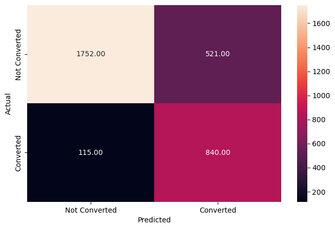

```python
# Checking performance on the training data
y_pred_train2 = (d_tree_tuned.predict(X_train))

metrics_score(y_train, y_pred_train2)
```

**Observations:**__****

A GridSearchCV tool was used on the data to find the best parameters for the model. The parameters are shown below in the box. The results show an improvement in the training model since the overfitting has been eliminated

**Let's check the model performance on the testing data**

```
              precision    recall  f1-score   support

           0       0.87      0.86      0.86       962
           1       0.69      0.70      0.70       422

    accuracy                           0.81      1384
   macro avg       0.78      0.78      0.78      1384
weighted avg       0.81      0.81      0.81      1384
```

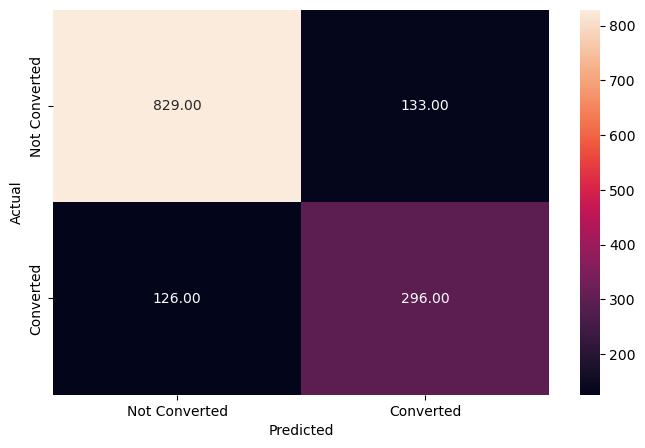

```python
y_pred_train2 = (d_tree_tuned.predict(X_test))

metrics_score(y_test, y_pred_test1)
```

### Visualizing the Decision Tree

**Let's visualize the tuned decision tree** and observe the decision rules:

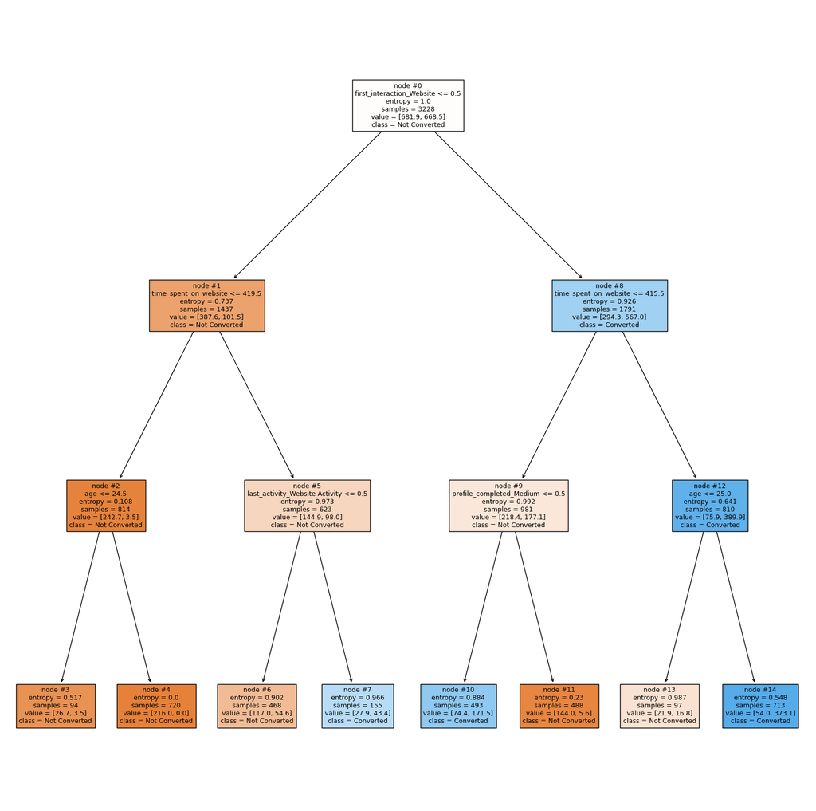

```python
features = list(X.columns)

plt.figure(figsize=(20, 20))

tree.plot_tree(d_tree_tuned, feature_names=features, filled=True, fontsize=9, node_ids=True, class_names=["Not Converted", "Converted"])

plt.show()
```

These are the variables that have the most influence over leads becoming paid customers according to this model:

- Time spent on website
- First Interaction - Website
- Profile Complete – Medium
- Age

The leaves with the lowest entropy are the most pure because they would only have a single classification

**Let's look at the feature importance** of the tuned decision tree model

```python
print (pd.DataFrame(d_tree_tuned.feature_importances_, columns = ["Imp"], index = X_train.columns).sort_values(by = 'Imp', ascending = False))
```

```
                                   Imp
time_spent_on_website          0.34814
first_interaction_Website      0.32718
profile_completed_Medium       0.23927
age                            0.06389
last_activity_Website Activity 0.02151
website_visits                 0.00000
page_views_per_visit           0.00000
current_occupation_Student     0.00000
current_occupation_Unemployed  0.00000
profile_completed_Low          0.00000
last_activity_Phone Activity   0.00000
print_media_type1_Yes          0.00000
print_media_type2_Yes          0.00000
digital_media_Yes              0.00000
educational_channels_Yes       0.00000
referral_Yes                   0.00000
```

This code will return the 'importance' value that the feature variables have on the target variable. The higher the value, the more importance that feature variable has. The variables with the highest values can be used when trying to determine the most important features or variables of a dataset. These results will assist in business decisions and finding solutions.

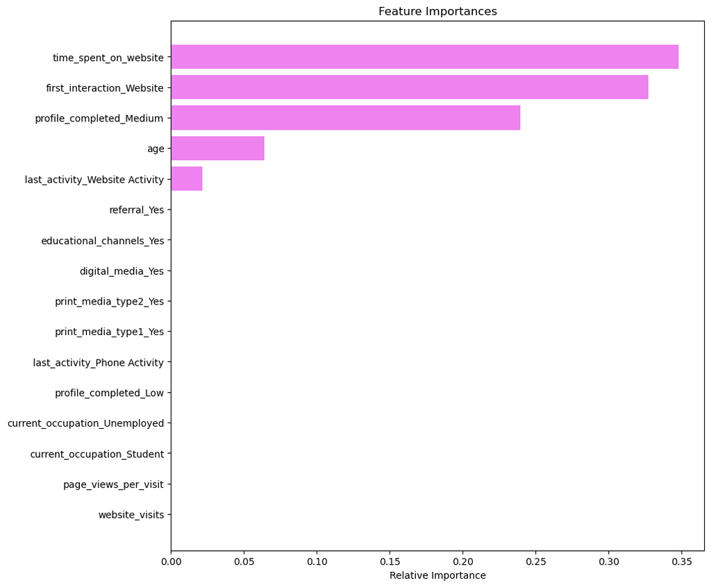

```python
# Plotting the feature importance
importances = d_tree_tuned.feature_importances_

indices = np.argsort(importances)

plt.figure(figsize = (10, 10))

plt.title('Feature Importances')

plt.barh(range(len(indices)), importances[indices], color = 'violet', align = 'center')

plt.yticks(range(len(indices)), [features[i] for i in indices])

plt.xlabel('Relative Importance')

plt.show()
```

Features with the most importance are shown on the graph

Any feature with no relative importance has no impact on the outcome of whether a lead will convert to a paid customer

### **Random Forest Classifier**

### Building Random Forest Model

```python
# Fitting the random forest tree classifier on the training data
rf_estimator =RandomForestClassifier( random_state = 1)

rf_estimator.fit(X_train, y_train)
```

```
RandomForestClassifier(random_state=1)
```

**Let's check the performance of the model on the training data**

```
              precision    recall  f1-score   support

           0       1.00      1.00      1.00      2273
           1       1.00      1.00      1.00       955

    accuracy                           1.00      3228
   macro avg       1.00      1.00      1.00      3228
weighted avg       1.00      1.00      1.00      3228
```

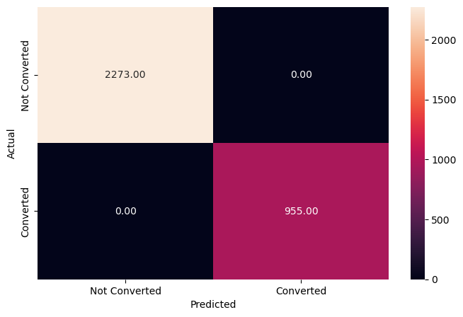

```python
# Checking performance on the training data
y_pred_train3 = rf_estimator.predict(X_train)
metrics_score(y_train, y_pred_train3)
```

This model is overfitting and needs to be tuned

**Let's check the performance on the testing data**

```
              precision    recall  f1-score   support

           0       0.87      0.91      0.89       962
           1       0.78      0.68      0.73       422

    accuracy                           0.84      1384
   macro avg       0.82      0.80      0.81      1384
weighted avg       0.84      0.84      0.84      1384
```

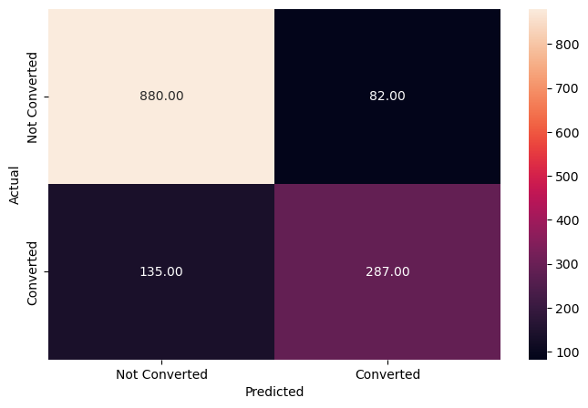

```python
# Checking performance on the testing data
y_pred_test3 = rf_estimator.predict(X_test)

metrics_score(y_test, y_pred_test3)
```

**Let's see if we can get a better model by tuning the random forest classifier**

### **Random Forest Classifier - Hyperparameter Tuning**

Let's try **tuning some of the important hyperparameters of the Random Forest Classifier**.

We will **not** tune the `criterion` hyperparameter as we know from hyperparameter tuning for decision trees that `entropy` is a better splitting criterion for this data.

```python
# Choose the type of classifier
rf_estimator_tuned = RandomForestClassifier(criterion = "entropy", random_state = 7)

 # Grid of parameters to choose from
parameters = {"n_estimators": [110, 120],
    "max_depth": [6, 7],
    "min_samples_leaf": [20, 25],
    "max_features": [0.8, 0.9],
    "max_samples": [0.9, 1],
    "class_weight": ["balanced",{0: 0.3, 1: 0.7}]
             }

# Type of scoring used to compare parameter combinations - recall score for class 1
scorer = metrics.make_scorer(recall_score, pos_label = 1)

# Run the grid search on the training data using scorer=scorer and cv=5
grid_obj = GridSearchCV(rf_estimator_tuned, parameters, scoring = scorer, cv = 5)
grid_obj = grid_obj.fit(X_train, y_train)

# Save the best estimator to variable rf_estimator_tuned
rf_estimator_tuned = grid_obj.best_estimator_
```

```python
# Fitting the best algorithm to the training data
rf_estimator_tuned.fit(X_train, y_train)
```

```
RandomForestClassifier(class_weight='balanced', criterion='entropy',
                       max_depth=6, max_features=0.8, max_samples=0.9,
                       min_samples_leaf=25, n_estimators=120, random_state=7)
```

```
              precision    recall  f1-score   support

           0       0.94      0.83      0.88      2273
           1       0.68      0.87      0.76       955

    accuracy                           0.84      3228
   macro avg       0.81      0.85      0.82      3228
weighted avg       0.86      0.84      0.84      3228
```

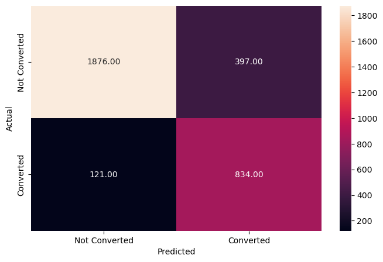

```python
# Checking performance on the training data
y_pred_train4 = rf_estimator_tuned.predict(X_train)
metrics_score(y_train, y_pred_train4)
```

**Let's check the model performance on the test data**

```
              precision    recall  f1-score   support

           0       0.93      0.83      0.87       962
           1       0.68      0.85      0.76       422

    accuracy                           0.83      1384
   macro avg       0.81      0.84      0.82      1384
weighted avg       0.85      0.83      0.84      1384
```

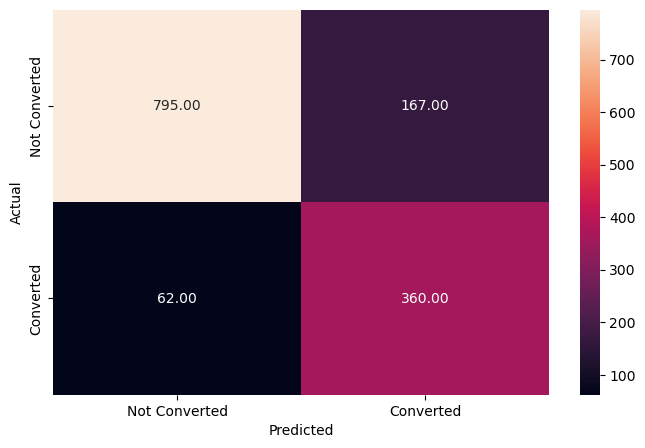

```python
# Checking performance on the test data
y_pred_train4 = rf_estimator_tuned.predict(X_test)
metrics_score(y_test, y_pred_train4)
```

**One of the drawbacks of ensemble models is that we lose the ability to obtain an interpretation of the model. We cannot observe the decision rules for random forests the way we did for decision trees. So, let's just check the feature importance of the model.**

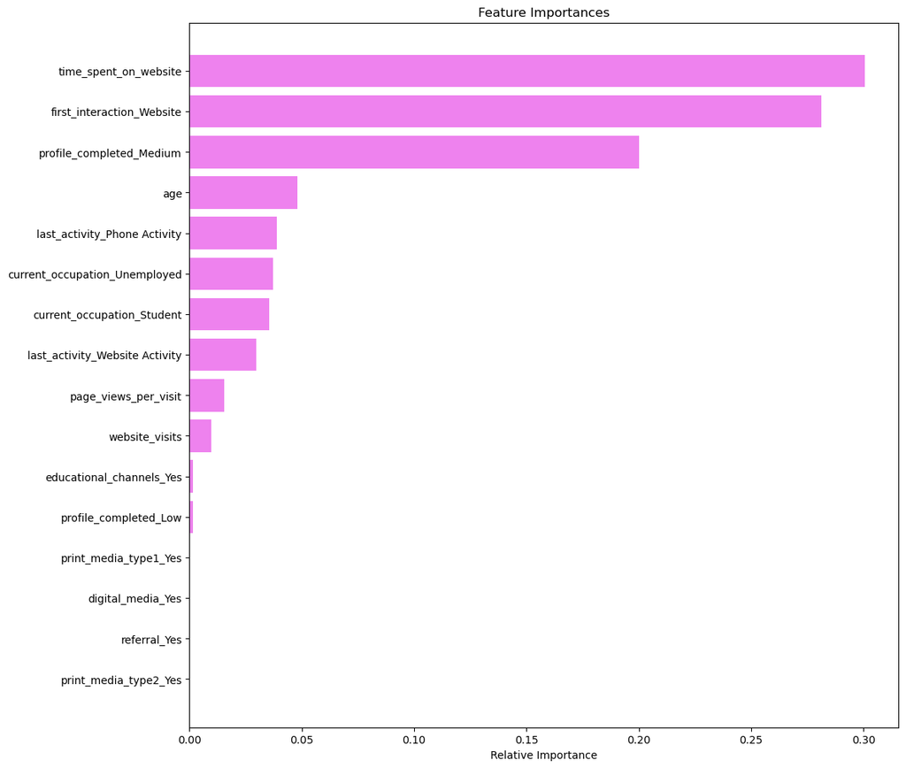

```python
importances = rf_estimator_tuned.feature_importances_

indices = np.argsort(importances)

feature_names = list(X.columns)

plt.figure(figsize = (12, 12))

plt.title('Feature Importances')

plt.barh(range(len(indices)), importances[indices], color = 'violet', align = 'center')

plt.yticks(range(len(indices)), [feature_names[i] for i in indices])

plt.xlabel('Relative Importance')

plt.show()
```

Below is a comparison of the important features that were identified through Decision Tree and Random Forest Model:

**Decision Tree

- Time Spent on the Website
- First Interaction - Website
- Profile Complete - Medium
- Age
- Last Activity - Website

The Random Forest Model had these and then some:

**Random Forest Model:

- Page views per visit
- Website visits
- Last Activity - Phone
- Current Occupation - Unemployed

## **Conclusion and Recommendations**

### Conclusions

There are pros and cons to using Decision Tree modeling:

Pros

- Easy to interpret
- Visual tree helps describe the outcome
- Minimal data prep required

Cons

- Prone to overfitting
- Requires feature manipulation and balancing
- Requires pruning for optimizing

There are also pros and cons to Random Forest Modeling:

Pros

- Can handle outliers and “noise”
- Works with both categorical and numerical variables
- Feature Importance function for problem solving/solutions

Cons

- Also prone to overfitting
- Larger data set and larger trees to analyze
- More time for interpretation needed by analyst

### **Business Recommendations:

Leads:

- Target leads that are looking for education options to support continuing and supplemental education Conduct further research to determine why leads are not completing their profiles
- BENEFIT: Allocating resources to individuals who are most likely to become paying customers will increase sales and efficiency

Support

- Leads prefer to seek out information via email vs phone or website. Continue to provide support roles for these duties
- Continue assigning resources to support both the website and the app. The results are almost a 50/50 split as far as consumer preference
- BENEFIT: Providing customer support across all options available to the customer will help drive sales and referrals

Advertisement

- ExtraaLearn may not be getting a positive return on investment (ROI) when it comes to newspaper and magazine advertisement. - - Evaluate the costs associated with the ads vs. the return. Reallocate these funds into Educational Channels
- BENEFIT: Investing in more media outlets that are known to attract leads will increase the amount of exposure and drive sales

Referral

- Develop an incentive plan for current customers to encourage them to make referrals. Include an incentive for new customers who receive a referral
- BENEFIT: Professional individuals tend to have a larger network pool than students. Use this to your advantage and drive sales through word of mouth

Customer Profile:

- Professionals or individuals looking t continue their education (non-students)
- Target age group 25-63, focusing on 45-55
- Leads that use internet for information vs. newspaper or magazine